# Calculating disease severity by adjusting for delays between onset and outcome during an outbreak

# Overview

This vignette outlines how to use `datadelay` to calculate disease severity during an ongoing outbreak. We wish to estimate either the *case fatality risk (CFR)* or *hospitalisation fatality risk (HFR)*. We do so using a method that uses a time series of cases and deaths with a delay distribution. The methods used here originate from Nishiura et al. (2009)<sup>[1]</sup>.

This vignette demonstrates how to implement the core functions within `datadelay`. Specifically, we will cover

1. Why naive estimates of CFR or HFR generated during an ongoing outbreak require adjusting, given out of sync time series are often being compared.
2. Arrive at estimates over time for the number of symptomatic individuals that will likely be known to have had an outcome $t$ days after symptom onset
3. Define an unbiased estimator to estimate the CFR or HFR from Nishiura et al (2009)<sup>[1]</sup>
4. Numerically implement the unbiased estimator numerically using maximum likelihood estimation to arrive at central estimates of the CFR or HFR, along with a confidence interval.

# Setup: installation and requirements

`datadelay` can be installed from Github, using the `devtools` package, with the following command:

```r
# installs the datadelay package from Github, as recommended on their repository:
# https://github.com/epiverse-trace/datadelay
if(!require("devtools")) install.packages("devtools")
devtools::install_github("epiverse-trace/datadelay")
```

Additionally, there are two more packages required for this analysis. The `epiparameter` package is the source of the delay distributions used and the `covidregionaldata` package is the source of the case and death time-series used in the second example in this vignette. We install `epiparameter` using the following command:

```r
# installs the epiparameter package from Github, as recommended on their repository:
# https://github.com/epiverse-trace/epiparameter
if(!require("remotes")) install.packages("remotes")
remotes::install_github("epiverse-trace/epiparameter")
```

We install `covidregionaldata` using the following command:

```r
# installs the stable version of covidregionaldata package from r-universe, as recommended on
# their repository:
# https://github.com/epiforecasts/covidregionaldata
install.packages("covidregionaldata", repos = "https://epiforecasts.r-universe.dev")
```

Now we load the three packages we need using the following commands:

```r
library(datadelay)
library(epiparameter)
library(covidregionaldata)
```

# Motivation

Key epidemiological quantities estimated in real-time often suffer from biases. In particular, dividing deaths-to-date by cases-to-date or hospitalisations-to-date leads to biased estimates of the CFR or HFR (respectively). This is because this calculation does not account for delays from confirmation of a case or hospitalisation to death.

If we had perfectly synchronised case and death incidence data, the basic versions of the CFR and HFR — defined as either the ratio of the total number of deaths and the total number of cases or hospitalisations (respectively) — would be accurate. These basic estimates are referred to as naive estimators. However, due to delays between onset or hospitalisation and death for all known diseases, this synchronisation is never true.

For example, suppose 10 people start showing symptoms of a specific disease on a given day and the end of that day all remain alive. Suppose that for the next 5 days, the numbers of new cases continue to rise until they reach 100 new cases on day 5. However, suppose that by day 5, all infected individuals remain alive. The naive estimate of the CFR would be zero calculated at the end of the first 5 days would be zero, because there would have been zero deaths in total. Even after deaths begin to occur, this lag between the ascertainment of a case or hospitalisation and outcome leads to a consistently biased estimate. Hence, adjusting for such delays using an appropriate delay distribution is essential for accurate estimates of severity.

# Data required

This method require three sets of data:

- A time-series of cases;
- A time-series of deaths;
- A delay distribution, describing the probability an individual will die $t$ days after they were initially exposed. Such distributions come from the literature, where studies have typically fit distributions to data describing the process.

In practice, the time-series of cases and deaths will already be together, given that they usually originate from sources that will have typically collated them into a single data file.

# Example with data from the 1976 Ebola outbreak in the Democratic Republic of the Congo

## Plotting the raw data

First of all, we plot the raw data

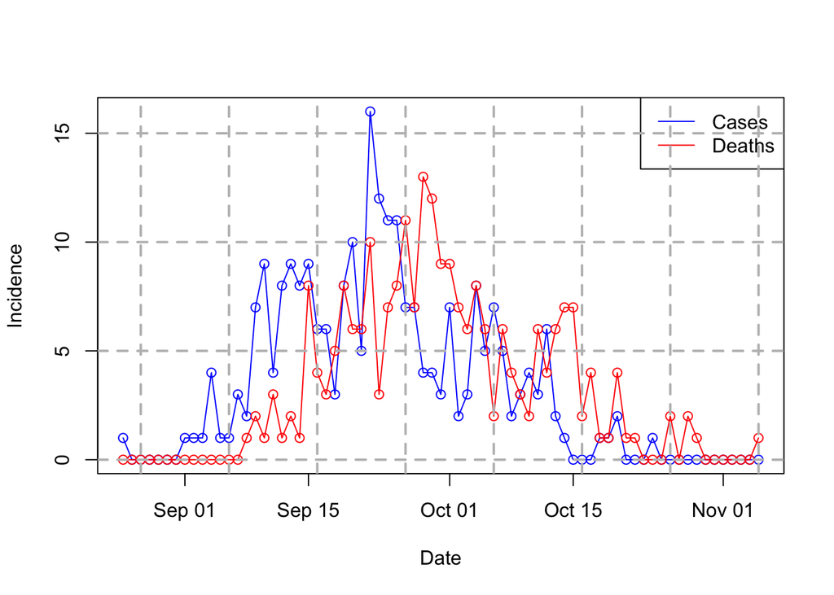

**Figure 1:** Incidence of cases and deaths over time, taken from the 1976 Ebola outbreak in the Democratic Republic of the Congo. Data retrieved from within the *datadelay* package

```r
data("ebola1976")
plot_raw_data(ebola1976, together = FALSE)
```

The argument `together = FALSE` of the `plot_raw_data()` function plots the case and death times series on a single figure, rather than two separate figures. This is useful if the raw values are similar and they can effectively share a scale. Otherwise, using the `together = TRUE` plot them on separate figures. The default argument is `together = TRUE`.

## The delay distribution

For this example, given that we are using case data and detection of a case is well-approximated by symptom onset, we use the distribution describing the delay between onset-to-death. As such, we retrieve such a distribution from the literature (reported here), using the `epidist_db()` function from the `epiparameter` package with the following command:

```r
onset_to_death_ebola <- epiparameter::epidist_db(
  disease = "Ebola Virus Disease",
  epi_dist = "onset_to_death",
  author = "Barry_etal")
```

To visualise this distribution, we evaluate it between 0 and 30 days, and plot the results over time:

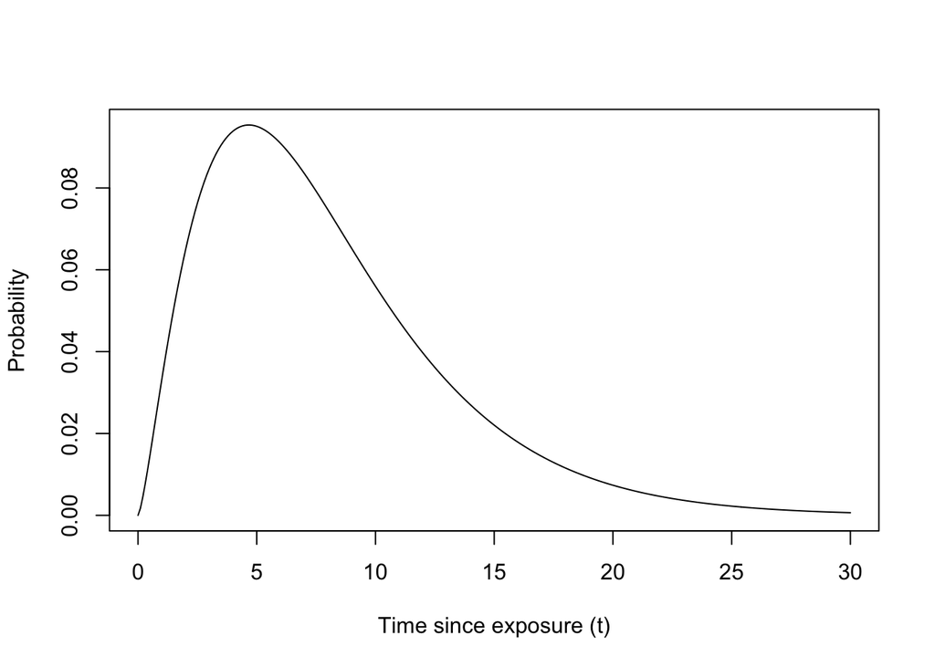

**Figure 2: Example plot of the appropriate delay distribution for the 1976 Ebola dataset.** We plot the onset-to-death distribution we use throughout this example for Ebola Virus Disease (EVD), reported in https://doi.org/10.1016/S0140-6736(18)31387-4.

```r
plot_epiparameter_distribution(onset_to_death_ebola, by = 0.1)
```

## Estimating the number and proportion of cases or hostpitalisations which have a known outcome over time

$$\begin{equation}
u_t = \frac{\sum_{i = 0}^t \sum_{j = 0}^\infty c_i f_{j - i}}{\sum_{i
= 0} c_i}
\end{equation}$$

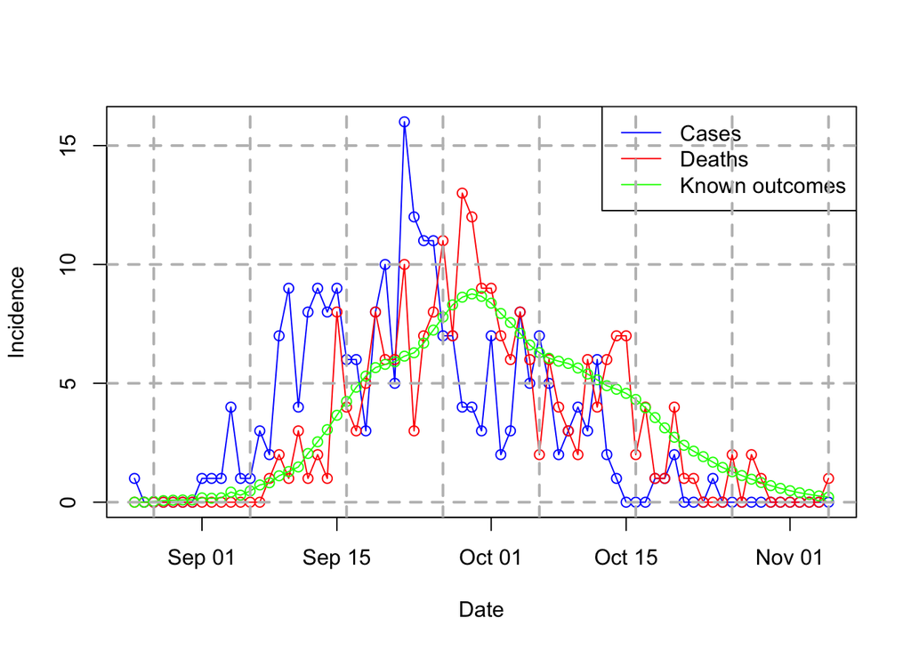

**Figure 3:** The same case and death time series for the 1976 Ebola outbreak in D.R.C., with estimated known outcomes included.

```r
df_known_outcomes_ebola <- known_outcomes(
  df_in = ebola1976,
  epi_dist = onset_to_death_ebola)

plot_known_outcomes(df_known_outcomes_ebola)
```

## Estimating the naive and corrected CFR

Once we calculate the proportion of cases with known outcomes, we apply the proportion to the number of cases to correct for the delay between onset-to-death. We do so by using the function `static_cfr()` from the `datadelay` package. This function estimates the proportion of known outcomes over time, and uses the estimate to correct the naive CFR estimate, if the argument `correct_for_delays = TRUE` is set. Otherwise, it calculates the naive CFR. We run this function using the following commands:

```r
# calculating the naive CFR
dt_ncfr_static_ebola <- static_cfr(
  ebola1976,
  correct_for_delays = FALSE) |>
  format_cfr_neatly(type = "Naive")

# calculating the corrected CFR
dt_ccfr_static_ebola <- static_cfr(
  ebola1976,
  correct_for_delays = TRUE,
  epi_dist = onset_to_death_ebola) |>
  format_cfr_neatly(type = "Corrected")

# putting the two results together
dt_static_clean_ebola <- rbind(dt_ncfr_static_ebola, dt_ccfr_static_ebola)
```

Once we have calculated both the naive and corrected CFR values, we put them together and make a table, using the `kable()` function from the `knitr` package, using the following command:

```r
knitr::kable(dt_static_clean_ebola, align = "c", col.names = c("CFR estimate: median (95% CrI)", "Type"))
```

| CFR estimate: median (95% CrI) | Type |
| --- | --- |
| 95.51% (95% CI: 92.11% - 97.74%) | Naive |
| 95.30% (95% CI: 83.60% - 100.00%) | Corrected |

# Example with data from the ongoing COVID-19 pandemic in the U.K.

We now perform a similar analysis with all of the same steps, with data taken from the ongoing COVID-19 epidemic in the U.K. For brevity, we describe the steps without methodological explanations throughout this example.

## Plotting the raw data

First of all, we plot the raw data on a national scale of the COVID-19 outbreak in the United Kingdom. We use `covidregionaldata` to retrieve the data, using the following command:

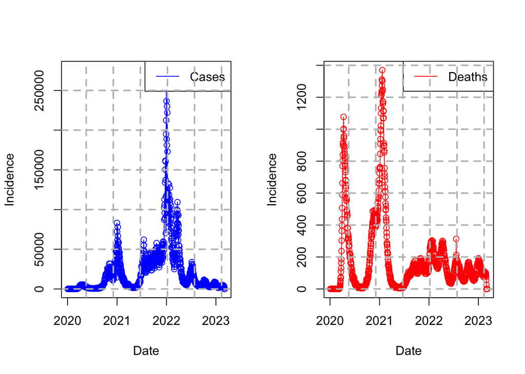

**Figure 4:** Incidence of cases and deaths over time for the ongoing COVID-19 outbreak in the U.K.

```r
covid_data_uk <- covidregionaldata::get_national_data(
  countries = "united kingdom", source = "who", verbose = FALSE) |>
  dplyr::rename(cases = cases_new, deaths = deaths_new)

plot_raw_data(covid_data_uk, together = TRUE)
```

## The delay distribution

We again retrieve the appropriate distribution (reported [here](https://doi.org/10.3390/jcm9020538)), using the `epidist_db()` function from the `epiparameter` package, using the following command:

```r
onset_to_death_covid <- epiparameter::epidist_db(
  disease = "COVID-19",
  epi_dist = "onset_to_death",
  author = "Linton_etal")
```

To visualise this distribution, we evaluate it between 0 and 30 days, and plot the results over time. We do so using the following command:

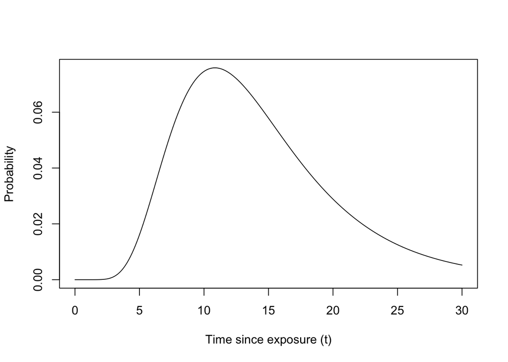

**Figure 5: Example plot of the appropriate delay distribution for the COVID-19 epidemic in the U.K.** We plot the onset-to-death distribution we use throughout this example for COVID-19, reported in https://doi.org/10.3390/jcm9020538.

```r
plot_epiparameter_distribution(onset_to_death_covid, by = 0.1)
```

## Estimating the number and proportion of cases or hostpitalisations which have a known outcome over time

We use the same method and implementation as in the Ebola example to calculate the number of known outcomes over time, using the following command:

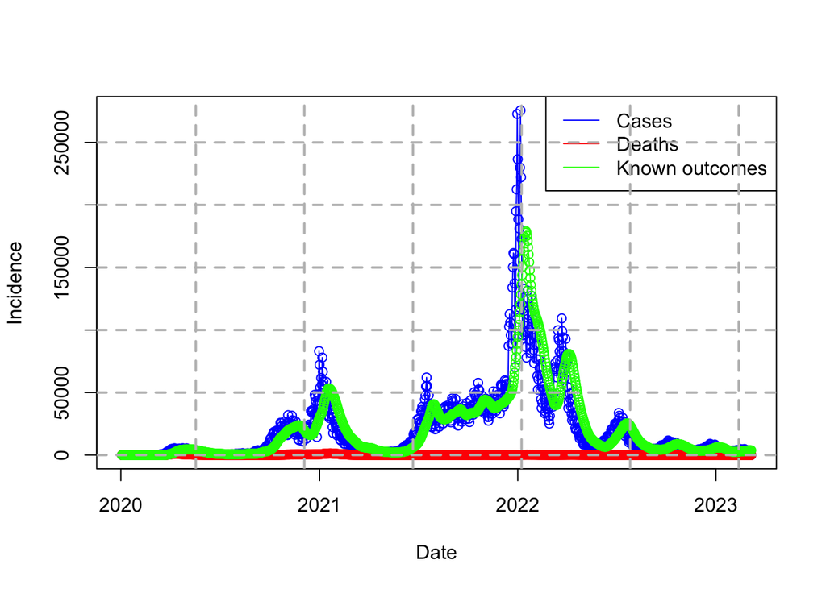

**Figure 6:** The same case and death time series for the ongoing COVID-19 epidemic in the U.K., with estimated known outcomes included.

```r
df_known_outcomes_covid <- known_outcomes(
  df_in = covid_data_uk,
  epi_dist = onset_to_death_covid)

plot_known_outcomes(df_known_outcomes_covid)
```

## Estimating the naive and corrected CFR

Using the same functions as the Ebola example, we calculate the naive and corrected CFRs for the COVID-19 epidemic in the U.K:

```r
# calculating the naive CFR
dt_ncfr_static_covid <- static_cfr(
  covid_data_uk,
  correct_for_delays = FALSE) |>
  format_cfr_neatly(type = "Naive")

# calculating the corrected CFR
dt_ccfr_static_covid <- static_cfr(
  covid_data_uk,
  correct_for_delays = TRUE,
  epi_dist = onset_to_death_covid) |>
  format_cfr_neatly(type = "Corrected")

# putting the two results together
dt_static_clean_covid <- rbind(dt_ncfr_static_covid, dt_ccfr_static_covid)
```

Once we have calculated both the naive and corrected CFR values, we put them together and make a table, using the `kable()` function from the `knitr` package, using the following command:

```r
knitr::kable(dt_static_clean_covid, align = "c", col.names = c("CFR estimate: median (95% CrI)", "Type"))
```

| CFR estimate: median (95% CrI) | Type |
| --- | --- |
| 0.85% (95% CI: 0.85% - 0.85%) | Naive |
| 0.90% (95% CI: 0.90% - 0.90%) | Corrected |

1

Nishiura H, Klinkenberg D, Roberts M, *et al.* Early epidemiological assessment of the virulence of emerging infectious diseases: A case study of an influenza pandemic. *PloS one* 2009;**4**:e6852.